**Important: Data Loading and Formats**

This section provides crucial information about the available data formats and how to load the Parquet files in R. Please review this carefully before proceeding with your analysis.

# 1 Info About Dataset Format

This dataset is available in two formats:

- **Multiband GeoTIFFs:** The original data is stored as multiband GeoTIFF files, with each file representing a specific week’s average from February 18th, 2000 to December 31st, 2023. These files were pulled directly from Google Earth Engine. The total size of the GeoTIFF dataset is 11.7 GB, and is split across 1244 files representing each week in date range.
- **Parquet Files:** For easier analysis, the data has been preprocessed and re-exported into annual Parquet files. Each Parquet file contains a full calendar year of data (e.g., `illinois_2000.parquet`, `illinois_2001.parquet`, etc.). The total size of all 24 Parquet files is 12 GB.

  **Important Note:** During the Parquet conversion, all pixels with no data across all 16 bands were omitted. This primarily filters out areas outside the Illinois boundary but within the GeoTIFF’s bounding box. Therefore, the Parquet files contain only pixels with at least one valid data point across all bands.

## 1.1 Loading Parquet Data in R

To read the Parquet files in R, you’ll need the `arrow` library. Here’s how to install and use it:

```r
# Install the arrow library (if you haven't already)
install.packages("arrow")

# Load the arrow library
library(arrow)

# Read the Parquet file
df <- read_parquet("data/transformed_data/illinois_2003.parquet")

# View the size of the dataset
print(dim(df))  # Prints the number of rows and columns

# View the column titles
print(names(df))

# View the data (in RStudio)
View(df)
```

**Note**

I’ve tested this on my machine and was successfully able to load the converted Parquet files into RStudio using the `arrow` library.

# 2 **Data Dictionary for Illinois GeoTIFF Metadata**

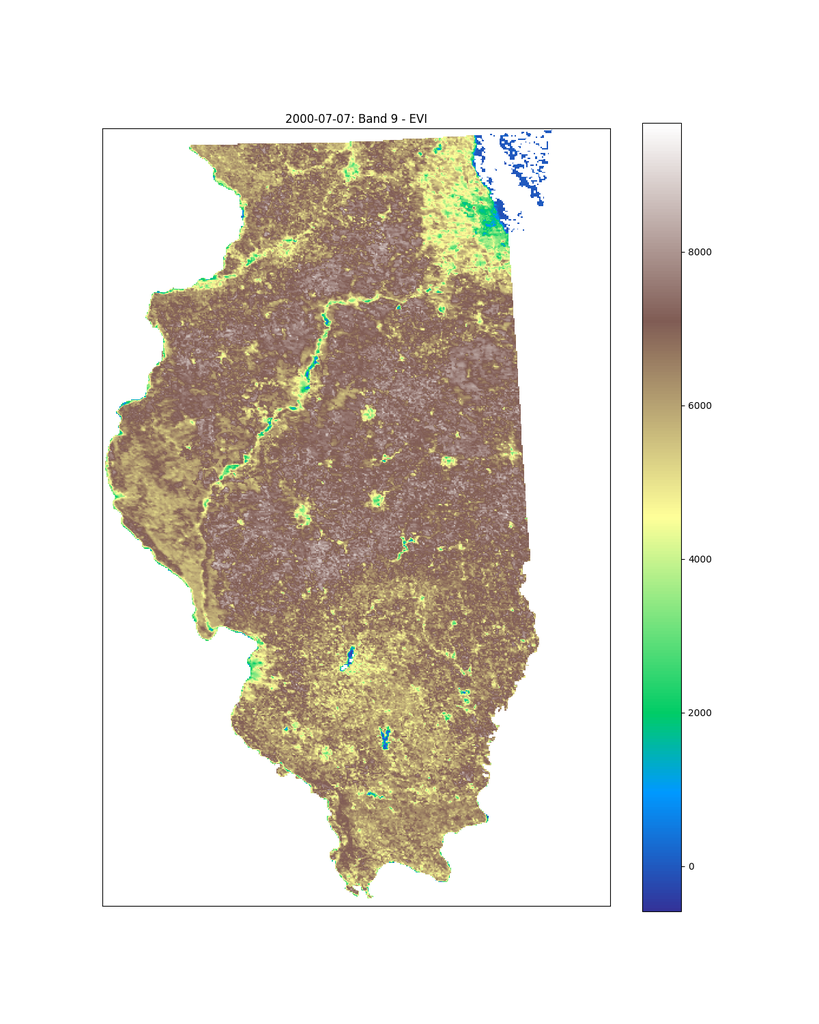

**General Metadata Summary**

**Band Explanation**

| Band Name | Description | Units | Data Type | NoData Value |
| --- | --- | --- | --- | --- |
| crop | Land cover type (1: non-cropland, 2: irrigated cropland, 3: rainfed cropland) | Category | float32 | None |
| dayl | Daylength | seconds | float32 | None |
| prcp | Precipitation | mm/day | float32 | None |
| srad | Downward shortwave radiation at the surface | W/m^2 | float32 | None |
| swe | Snow water equivalent | kg/m^2 | float32 | None |
| tmax | Daily maximum 2-meter air temperature | degrees C | float32 | None |
| tmin | Daily minimum 2-meter air temperature | degrees C | float32 | None |
| vp | Water vapor pressure | Pa | float32 | None |
| EVI | Enhanced Vegetation Index | unitless | float32 | None |
| NDVI | Normalized Difference Vegetation Index | unitless | float32 | None |
| ET | Evapotranspiration | mm/day | float32 | None |
| LE | Latent heat flux | W/m^2 | float32 | None |
| PET | Potential evapotranspiration | mm/day | float32 | None |
| PLE | Potential latent heat flux | W/m^2 | float32 | None |
| FPAR | Fraction of Photosynthetically Active Radiation | unitless | float32 | None |
| LAI | Leaf Area Index | m<sup>2/m</sup>2 | float32 | None |

## 2.2 **Notes on Original Datasets**

1. **Daymet v4 (Meteorologic Data)**
   - North America
   - 1980.01.01 to 2023.12.31
   - 1000m x 1000m, Daily
   - EEID: [NASA/ORNL/DAYMET_V4](https://developers.google.com/earth-engine/datasets/catalog/NASA_ORNL_DAYMET_V4)
2. **MODIS (Terra 1km) - EVI/NDVI**
   - Global
   - 2000.02.18 to 2024.10.31
   - 1000m x 1000m, 16-day Composite
   - EEID: [MODIS/061/MOD13A2](https://developers.google.com/earth-engine/datasets/catalog/MODIS_061_MOD13A2)
3. **MODIS (Terra 500m) - ET/LE**
   - Global
   - 2000.01.01 to 2023.12.27
   - 500m x 500m, 8-Day composite
   - EEID: [MODIS/061/MOD16A2GF](https://developers.google.com/earth-engine/datasets/catalog/MODIS_061_MOD16A2GF)
4. **MODIS (Terra 500m) - Leaf Area and FPAR**
   - Global
   - 2000.02.18 to 2024.11.08
   - 500m x 500m, 8-Day composite
   - EEID: [MODIS/061/MOD15A2H](https://developers.google.com/earth-engine/datasets/catalog/MODIS_061_MOD15A2H)
5. **Global Food-Support Analysis Data (GFSAD) Cropland**
   - Global
   - 2010.01.01
   - 1000m x 1000m, one-time (2010)
   - EEID: [USGS/GFSAD1000_V1](https://developers.google.com/earth-engine/datasets/catalog/USGS_GFSAD1000_V1)

## 2.3 **Types of Vegetation Metrics**

- **Evapotranspiration (ET):** Measures the total water loss from soil and plants; higher ET indicates active plant growth and sufficient water availability. Over 25 years, an overall decrease in ET due to climate change could indicate reduced plant activity or increased water stress.
- **Fraction of Photosynthetically Active Radiation (FPAR):** Represents the fraction of sunlight absorbed by vegetation for photosynthesis; higher FPAR denotes healthier, more productive crops. Over 25 years, a declining FPAR trend could indicate an overall reduction in crop canopy density.
- **Leaf Area Index (LAI):** Quantifies the total leaf area per unit ground area; higher LAI reflects denser foliage and robust plant growth. Over 25 years, an overall decrease in LAI over time could point to diminished vegetation cover or stunted growth.
- **Enhanced Vegetation Index (EVI):** An index that enhances vegetation signals by reducing atmospheric and soil background noise; higher EVI values correspond to healthier vegetation. Over 25 years, a downward trend in EVI might indicate declining vegetation vigor.
- **Normalized Difference Vegetation Index (NDVI):** Assesses vegetation greenness by comparing red and near-infrared reflectance; higher NDVI values signify healthier, greener vegetation. Over 25 years, a decrease in NDVI over 25 years could suggest reduced vegetation health or coverage.

  **NDVI and EVI** capture vegetation greenness and vigor, offering a direct assessment of plant health, whereas **LAI**, **FPAR**, and **ET** provide information on structural and functional aspects of vegetation. The scientific basis for preferring NDVI/EVI lies in their sensitivity to chlorophyll content and ability to detect changes in vegetation health more directly. The general hypothesis is: if the climate in 2000 was more favorable for crops than in 2024, we would expect to see higher values of ET, FPAR, LAI, EVI, and NDVI in 2000, reflecting more vigorous plant growth, denser foliage, and healthier vegetation due to optimal growing conditions.